# Анализ рынка компьютерных игр

Определим самые популярные жанры игр по регионам (топ-5).

```python
# получаем срез данных по регионам
data_genre = data2011[['genre', 'na_sales', 'eu_sales', 'jp_sales']] \
    .groupby('genre', as_index=False) \
    .agg({'na_sales': 'sum', 'eu_sales': 'sum', 'jp_sales': 'sum'}) \
    .melt(id_vars=['genre']) \
    .sort_values('value', ascending=False)
data_genre.head()
```

|  | genre | variable | value |
| --- | --- | --- | --- |
| 0 | Action | na_sales | 177.84 |
| 12 | Action | eu_sales | 159.34 |
| 8 | Shooter | na_sales | 144.77 |
| 20 | Shooter | eu_sales | 113.47 |
| 10 | Sports | na_sales | 81.53 |

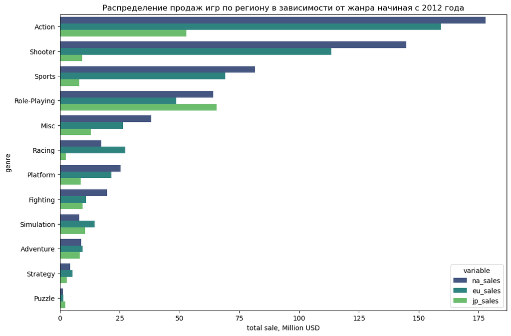

```python
# строим график распределения продаж игр по регионам в зависимости от жанра начиная с 2012 года
plt.figure(figsize=(12, 8))

# задание параметров построения графика
ax = sns.barplot(y=data_genre.genre,
                 x=data_genre.value,

                 color='#6925c2',
                 palette='viridis',
                 hue=data_genre.variable);

# подписи осей и названия
plt.xlabel('total sale, Million USD')
plt.title('Распределение продаж игр по региону в зависимости от жанра начиная с 2012 года');
```

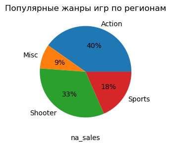

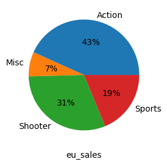

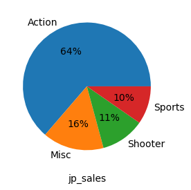

```python
# строим круговые диаграммы
data_genre5 = ["Action", "Shooter", "Sports", "Role-playing", "Misc"]
data_genre_all = data2011.query('genre in @data_genre5')
ax=data_bar_na = data_genre_all.pivot_table(index='genre',  values='na_sales', aggfunc=('sum')).plot(kind='pie', y='na_sales', autopct='%1.0f%%', figsize=(5, 3))
ax1=data_bar_na = data_genre_all.pivot_table(index='genre',  values='eu_sales', aggfunc=('sum')).plot(kind='pie', y='eu_sales', autopct='%1.0f%%', figsize=(5, 3))
ax2=data_bar_na = data_genre_all.pivot_table(index='genre',  values='jp_sales', aggfunc=('sum')).plot(kind='pie', y='jp_sales', autopct='%1.0f%%', figsize=(5, 3))

ax.set(title='Популярные жанры игр по регионам',
xlabel = 'na_sales', ylabel='')
ax1.set(xlabel = 'eu_sales', ylabel='')
ax2.set(xlabel = 'jp_sales', ylabel='')
ax.legend().set_visible(False)
ax1.legend().set_visible(False)
ax2.legend().set_visible(False)
plt.show()
```

Определим влияние рейтинга ESRB на продажи в отдельном регионе:

```python
# получаем срез данных по рейтингу
data_rating = data2011[['rating', 'na_sales', 'eu_sales', 'jp_sales']] \
    .groupby('rating', as_index=False) \
    .agg({'na_sales': 'sum', 'eu_sales': 'sum', 'jp_sales': 'sum'}) \
    .melt(id_vars=['rating']) \
    .sort_values('value', ascending=False)
```

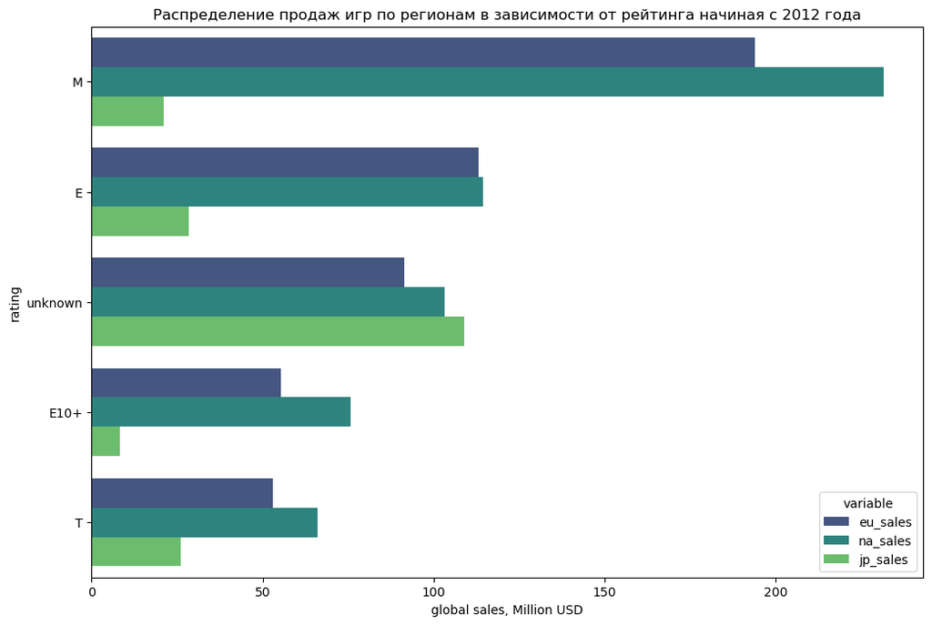

```python
# строим график распределения продаж по регионам в зависимости от рейтинга
plt.figure(figsize=(12, 8))

# задание параметров построения графика
ax = sns.barplot(y=data_rating.rating,
                 x=data_rating.value,
                 orient='h',
                 color='#6925c2',
                 palette='viridis',
                 hue=data_rating.variable,
                 hue_order=['eu_sales', 'na_sales', 'jp_sales']);

# подписи осей и названия
plt.xlabel('global sales, Million USD')
plt.title('Распределение продаж игр по регионам в зависимости от рейтинга начиная с 2012 года');
```

**Выводы:**

После проведенного анализа можем заключить, что портрет пользователя регионов Северная Америка и Европа не сильно различается, в то время, как азиатские потребители выделяются по проанализированным параметрам (выбор платформы, любимый жанр, ситуация с рейтингом наиболее продаваемых игра). Следовательно стоит учитывать историко-культурные различия регионов, отражающиеся непосредственно в предпочтениях пользоватлей, при ведении бизнеса.

## Шаг Проверяем гипотезы

**Проверка гипотезы №1.**

Для проверки данной гипотезы, необходимо воспользоваться методом проверки гипотезы о равенстве средних двух генеральных совокупностей. t-тест используется для проверки значимости различий между средними генеральных совокупностей. Таким образом:

Нулевая гипотеза: средние пользовательские рейтинги платформ Xbox One и PC одинаковые. Альтернативная гипотеза: средние пользовательские рейтинги платформ Xbox One и PC различаются.

Чтобы проверить гипотезу о равенстве среднего двух генеральных совокупностей по взятым из них выборкам, воспользуюсь методом: scipy.stats.ttest_ind().

```python
data_1 = data[(data['year_of_release'] >2011) & (data['user_score'] !=-1)]
```

```python
platform_xone = data_1[data_1['platform'] =='XOne']['user_score'].mean()
platform_pc = data_1[data_1['platform'] =='PC']['user_score'].mean()
platform_pc/platform_xone
```

```
0.985771860611023
```

```python
platform_xone = data_1[data_1['platform'] =='XOne']['user_score']
platform_pc = data_1[data_1['platform'] =='PC']['user_score']

results = st.ttest_ind(platform_xone, platform_pc, equal_var = False)
alpha = 0.05

# вывод значения p-value на экран
print('p-значение:', results.pvalue)

# условный оператор с выводом строки с ответом
if results.pvalue < alpha:
    print('Отвергаем нулевую гипотезу')
else:
    print('Не получилось отвергнуть нулевую гипотезу')
```

```
p-значение: 0.5489537965134912
Не получилось отвергнуть нулевую гипотезу
```

По итогам проверки гипотез получили следующее:

Нулевую гипотезу отвергнуть не удалось. Таким образом, у нас имеются сильные основания полагать, что средние показатели рейтинга платформы Xbox One и PC одинаковые.

**Проверка гипотезы №2.**

Для проверки данной гипотезы, необходимо воспользоваться методом проверки гипотезы о равенстве средних двух генеральных совокупностей. t-тест используется для проверки значимости различий между средними генеральных совокупностей. Таким образом:

Нулевая гипотеза: средние пользовательские рейтинги жанров Action и Sports одинаковые. Альтернативная гипотеза: средние пользовательские рейтинги жанров Action и Sports разные.

Чтобы проверить гипотезу о равенстве среднего двух генеральных совокупностей по взятым из них выборкам, воспользуюсь методом: scipy.stats.ttest_ind().

```python
sample_action = data_1.query('genre == "Action"').user_score.mean()
sample_sports = data_1.query('genre == "Sports"').user_score.mean()
sample_sports/sample_action
```

```
0.7993932928909806
```

```python
# произведем выборку требующихся для проверки гипотезы данных
genre_action = data_1.query('genre == "Action"').user_score
genre_sports = data_1.query('genre == "Sports"').user_score

results = st.ttest_ind(genre_action, genre_sports, equal_var = False)
alpha = 0.05

# вывод значения p-value на экран
print('p-значение:', results.pvalue)

# условный оператор с выводом строки с ответом
if results.pvalue < alpha:
    print('Отвергаем нулевую гипотезу')
else:
    print('Не получилось отвергнуть нулевую гипотезу')
```

```
p-значение: 4.24307776572644e-20
Отвергаем нулевую гипотезу
```

По итогам проверки гипотез получили следующее:

Нулевая гипотеза не подтвердилась, средние пользовательские рейтинги жанров Action (англ. «действие», экшен-игры) и Sports (англ. «спортивные соревнования») разные.

**Выводы:**

На данном этапе нам удалось проверить две гипотезы о средних пользовательских рейтингах. В результате проверки гипотез, мы теперь можем с большой долей уверенности полагать, что:

средние пользовательские рейтинги платформ Xbox One и PC одинаковые; средние пользовательские рейтинги жанров Action и Sports различны.

## Общий вывод:

Больше всего игр продавлось в 2008-2009 годы. На данный момент отрасль видео игр находится в стадии спада; Жизненный цикл платформы видеоигр составляет порядка 6-7 лет. На ближайшее время перспективными являются платформы: PS4, XOne. Не хватет оценки пользователей, поэтому надо рекламировать данные платформы.Наиболее популярные жанры игр за последние 5 лет: Action, Shooter и Role-Playing. Портрет пользователя регионов Северная Америка и Европа не сильно различается по предпочтениям, в то время, как азиатские потребители выделяются, как выбором платформы, так и любимым жанром. Следовательно стоит учитывать историко-культурные различия регионов, отражающиеся непосредственно в предпочтениях пользоватлей, при ведении бизнеса. Оценки критиков и оценки пользователей не сильно влияют на динамику продаж (в обоих случаях наблюдается слабая корреляция). В результате проверки гипотез нам удалось узнать,что: средние пользовательские рейтинги платформ Xbox One и PC одинаковые; средние пользовательские рейтинги жанров Action и Sports различны.

Рекомендации

Необходимо делать ставку на продажу игр для платформ PS4, XOne с жанрами Action, Shooter и Role-Playing учитывая специфику азиатского рынка при запуска рекламных компаний.